# lab4

Keven Lin

10/19/2021

```r
library(readxl)
library(tidyverse)
```

```r
library(ggplot2)
library(ggthemes)
defense <- read_excel('cyclonesFootball2020.xlsx', sheet='Defensive')
offensive <- read_excel('cyclonesFootball2020.xlsx', sheet='Offensive')
biography <- read_excel('cyclonesFootball2020.xlsx', sheet='Biography')
```

# Part one: Cleaning data

Although the three Excel sheets are loaded into R, they are not useful before some cleaning. Manipulate the three imported data frames:

1. The player names and opponent names should be factors.

```r
defense$Name = factor(defense$Name)
offensive$Name = factor(offensive$Name)
biography$Name = factor(biography$Name)

defense$Opponent_Opponent = factor(defense$Opponent_Opponent)
offensive$Opponent_Opponent = factor(offensive$Opponent_Opponent)
```

2. All offensive and defensive statistics should be numerical. The Weight column in biogrpahy should also be numeric. (Optional: Read ?across and learn to mutate multiple columns simultaneously using the across function in dplyr)

```r
defense = defense %>% mutate(across(Tackles_Solo:Pass_PB, ~as.numeric(.)))

offensive = offensive %>% mutate(across(c(Receiving_REC, Receiving_YDS, Receiving_TD, Rushing_ATT, Rushing_YDS, Rushing_TD, Passing_YDS, Passing_TD, Passing_INT), ~as.numeric(.)))

offensive$`Passing_CMP-ATT` = gsub("\r?\n|\r", " ", offensive$`Passing_CMP-ATT`)
offensive$`Passing_CMP-ATT` = gsub("\\s", "", offensive$`Passing_CMP-ATT`)

offensive = offensive %>% mutate(Passing_CMP = as.numeric(substr(`Passing_CMP-ATT`, 1, 2)))
```

```r
offensive = offensive %>% mutate(Passing_ATT = as.numeric(substr(`Passing_CMP-ATT`, 4, 5)))
offensive = within(offensive, rm(`Passing_CMP-ATT`))

biography$Weight = as.numeric(biography$Weight)
```

3. The Height column in biography should be numeric. (Hint: Use a unit that works well)

```r
biography = biography %>% mutate(Height_Feet = as.numeric(substr(Height, 1, 1)))
biography = biography %>% mutate(Height_Inch = as.numeric(substr(Height, 3, 4)))
biography = biography %>% mutate(Height = Height_Feet + (Height_Inch / 12))
biography = within(biography, rm(Height_Feet, Height_Inch))
# biography$Height
```

4. Add a column to both defense and offense indicating whether it is the first or the second game versus an opponent. We had a single game versus each opponent except for Oklahoma, which we played against twice. (Hint: You can use group_by(), mutate(), and row_number())

```r
offensive = offensive %>% group_by(Name) %>% mutate(GameNumber = ifelse( duplicated(Opponent_Opponent), 2, 1))
defense = defense %>% group_by(Name) %>% mutate(GameNumber = ifelse( duplicated(Opponent_Opponent), 2, 1))

str(offensive)
```

```
## grouped_df [156 x 14] (S3: grouped_df/tbl_df/tbl/data.frame)
##  $ Name             : Factor w/ 16 levels "Akers, Landen",..: 1 1 1 1 1 1 1 1 1 1 ...
##  $ Opponent_Opponent: Factor w/ 11 levels "Baylor","Kansas",..: 4 8 5 10 6 2 1 3 9 11 ...
##  $ Receiving_REC    : num [1:156] 0 2 1 4 0 6 1 0 1 1 ...
##  $ Receiving_YDS    : num [1:156] 0 60 35 34 0 76 11 0 10 2 ...
##  $ Receiving_TD     : num [1:156] 0 0 0 0 0 0 0 0 0 1 ...
##  $ Rushing_ATT      : num [1:156] NA NA NA NA NA NA NA NA NA NA ...
##  $ Rushing_YDS      : num [1:156] NA NA NA NA NA NA NA NA NA NA ...
##  $ Rushing_TD       : num [1:156] NA NA NA NA NA NA NA NA NA NA ...
##  $ Passing_YDS      : num [1:156] NA NA NA NA NA NA NA NA NA NA ...
##  $ Passing_TD       : num [1:156] NA NA NA NA NA NA NA NA NA NA ...
##  $ Passing_INT      : num [1:156] NA NA NA NA NA NA NA NA NA NA ...
##  $ Passing_CMP      : num [1:156] NA NA NA NA NA NA NA NA NA NA ...
##  $ Passing_ATT      : num [1:156] NA NA NA NA NA NA NA NA NA NA ...
##  $ GameNumber       : num [1:156] 1 1 1 1 1 1 1 1 1 1 ...
##  - attr(*, "groups")= tibble [16 x 2] (S3: tbl_df/tbl/data.frame)
##   ..$ Name : Factor w/ 16 levels "Akers, Landen",..: 1 2 3 4 5 6 7 8 9 10 ...
##   ..$ .rows: list<int> [1:16]
##   .. ..$ : int [1:12] 1 2 3 4 5 6 7 8 9 10 ...
##   .. ..$ : int [1:11] 107 108 109 110 111 112 113 114 115 116 ...
##   .. ..$ : int [1:5] 136 137 138 139 140
##   .. ..$ : int [1:10] 13 14 15 16 17 18 19 20 21 22
##   .. ..$ : int [1:12] 145 146 147 148 149 150 151 152 153 154 ...
##   .. ..$ : int [1:3] 93 94 95
##   .. ..$ : int [1:12] 81 82 83 84 85 86 87 88 89 90 ...
##   .. ..$ : int [1:12] 23 24 25 26 27 28 29 30 31 32 ...
##   .. ..$ : int [1:4] 141 142 143 144
##   .. ..$ : int [1:11] 96 97 98 99 100 101 102 103 104 105 ...
##   .. ..$ : int [1:6] 130 131 132 133 134 135
##   .. ..$ : int [1:12] 35 36 37 38 39 40 41 42 43 44 ...
##   .. ..$ : int [1:12] 47 48 49 50 51 52 53 54 55 56 ...
##   .. ..$ : int [1:11] 59 60 61 62 63 64 65 66 67 68 ...
##   .. ..$ : int [1:12] 118 119 120 121 122 123 124 125 126 127 ...
##   .. ..$ : int [1:11] 70 71 72 73 74 75 76 77 78 79 ...
##   .. ..@ ptype: int(0)
##   ..- attr(*, ".drop")= logi TRUE
```

By cleaning the three data frames in R, at the end of this step you should have the following three clean data frames: defClean, offClean, and bioClean. Print the structures of these data frames using str().

```r
defClean = defense
offClean = offensive
bioClean = biography
str(defClean)
```

```
## grouped_df [372 x 12] (S3: grouped_df/tbl_df/tbl/data.frame)
##  $ Name             : Factor w/ 37 levels "Akers, Landen",..: 26 26 26 26 26 26 26 26 26 26 ...
##  $ Opponent_Opponent: Factor w/ 11 levels "Baylor","Kansas",..: 4 8 5 10 6 2 1 3 9 11 ...
##  $ Tackles_Solo     : num [1:372] 2 6 6 3 7 4 7 4 4 2 ...
##  $ Tackles_ASST     : num [1:372] 4 4 5 0 3 1 4 3 9 3 ...
##  $ Tackles_TFL      : num [1:372] 1 0 1.5 1 1 0 1.5 2.5 1.5 0 ...
##  $ Tackles_Sack     : num [1:372] 0 0 0.5 0 0 0 0 1 0 0 ...
##  $ Turnover_FF      : num [1:372] 0 0 0 0 0 0 0 0 0 0 ...
##  $ Turnover_FR      : num [1:372] 0 0 0 0 0 0 0 0 0 0 ...
##  $ Turnover_INT     : num [1:372] 0 1 0 0 1 0 1 1 0 0 ...
##  $ Pass_QBH         : num [1:372] 0 0 1 0 0 0 2 1 0 0 ...
##  $ Pass_PB          : num [1:372] 0 0 0 0 0 1 0 0 1 0 ...
##  $ GameNumber       : num [1:372] 1 1 1 1 1 1 1 1 1 1 ...
##  - attr(*, "groups")= tibble [37 x 2] (S3: tbl_df/tbl/data.frame)
##   ..$ Name : Factor w/ 37 levels "Akers, Landen",..: 1 2 3 4 5 6 7 8 9 10 ...
##   ..$ .rows: list<int> [1:37]
##   .. ..$ : int [1:12] 193 194 195 196 197 198 199 200 201 202 ...
##   .. ..$ : int [1:9] 61 62 63 64 65 66 67 68 69
##   .. ..$ : int [1:12] 49 50 51 52 53 54 55 56 57 58 ...
##   .. ..$ : int [1:12] 140 141 142 143 144 145 146 147 148 149 ...
##   .. ..$ : int [1:11] 129 130 131 132 133 134 135 136 137 138 ...
##   .. ..$ : int [1:10] 277 278 279 280 281 282 283 284 285 286
##   .. ..$ : int [1:6] 244 245 246 247 248 249
##   .. ..$ : int [1:12] 205 206 207 208 209 210 211 212 213 214 ...
##   .. ..$ : int [1:12] 287 288 289 290 291 292 293 294 295 296 ...
##   .. ..$ : int [1:11] 152 153 154 155 156 157 158 159 160 161 ...
##   .. ..$ : int [1:12] 13 14 15 16 17 18 19 20 21 22 ...
##   .. ..$ : int [1:12] 299 300 301 302 303 304 305 306 307 308 ...
##   .. ..$ : int [1:2] 311 312
##   .. ..$ : int [1:8] 185 186 187 188 189 190 191 192
##   .. ..$ : int [1:12] 70 71 72 73 74 75 76 77 78 79 ...
##   .. ..$ : int [1:10] 175 176 177 178 179 180 181 182 183 184
##   .. ..$ : int [1:4] 313 314 315 316
##   .. ..$ : int [1:7] 259 260 261 262 263 264 265
##   .. ..$ : int [1:12] 317 318 319 320 321 322 323 324 325 326 ...
##   .. ..$ : int [1:3] 329 330 331
##   .. ..$ : int [1:9] 250 251 252 253 254 255 256 257 258
##   .. ..$ : int [1:12] 117 118 119 120 121 122 123 124 125 126 ...
##   .. ..$ : int [1:6] 217 218 219 220 221 222
##   .. ..$ : int [1:12] 223 224 225 226 227 228 229 230 231 232 ...
##   .. ..$ : int [1:12] 332 333 334 335 336 337 338 339 340 341 ...
##   .. ..$ : int [1:12] 1 2 3 4 5 6 7 8 9 10 ...
##   .. ..$ : int [1:11] 266 267 268 269 270 271 272 273 274 275 ...
##   .. ..$ : int [1:11] 344 345 346 347 348 349 350 351 352 353 ...
##   .. ..$ : int [1:11] 355 356 357 358 359 360 361 362 363 364 ...
##   .. ..$ : int [1:7] 366 367 368 369 370 371 372
##   .. ..$ : int [1:9] 235 236 237 238 239 240 241 242 243
##   .. ..$ : int [1:12] 82 83 84 85 86 87 88 89 90 91 ...
##   .. ..$ : int [1:12] 25 26 27 28 29 30 31 32 33 34 ...
##   .. ..$ : int [1:12] 105 106 107 108 109 110 111 112 113 114 ...
##   .. ..$ : int [1:12] 163 164 165 166 167 168 169 170 171 172 ...
##   .. ..$ : int [1:11] 94 95 96 97 98 99 100 101 102 103 ...
##   .. ..$ : int [1:12] 37 38 39 40 41 42 43 44 45 46 ...
##   .. ..@ ptype: int(0)
##   ..- attr(*, ".drop")= logi TRUE
```

```r
str(offClean)
```

```
## grouped_df [156 x 14] (S3: grouped_df/tbl_df/tbl/data.frame)
##  $ Name             : Factor w/ 16 levels "Akers, Landen",..: 1 1 1 1 1 1 1 1 1 1 ...
##  $ Opponent_Opponent: Factor w/ 11 levels "Baylor","Kansas",..: 4 8 5 10 6 2 1 3 9 11 ...
##  $ Receiving_REC    : num [1:156] 0 2 1 4 0 6 1 0 1 1 ...
##  $ Receiving_YDS    : num [1:156] 0 60 35 34 0 76 11 0 10 2 ...
##  $ Receiving_TD     : num [1:156] 0 0 0 0 0 0 0 0 0 1 ...
##  $ Rushing_ATT      : num [1:156] NA NA NA NA NA NA NA NA NA NA ...
##  $ Rushing_YDS      : num [1:156] NA NA NA NA NA NA NA NA NA NA ...
##  $ Rushing_TD       : num [1:156] NA NA NA NA NA NA NA NA NA NA ...
##  $ Passing_YDS      : num [1:156] NA NA NA NA NA NA NA NA NA NA ...
##  $ Passing_TD       : num [1:156] NA NA NA NA NA NA NA NA NA NA ...
##  $ Passing_INT      : num [1:156] NA NA NA NA NA NA NA NA NA NA ...
##  $ Passing_CMP      : num [1:156] NA NA NA NA NA NA NA NA NA NA ...
##  $ Passing_ATT      : num [1:156] NA NA NA NA NA NA NA NA NA NA ...
##  $ GameNumber       : num [1:156] 1 1 1 1 1 1 1 1 1 1 ...
##  - attr(*, "groups")= tibble [16 x 2] (S3: tbl_df/tbl/data.frame)
##   ..$ Name : Factor w/ 16 levels "Akers, Landen",..: 1 2 3 4 5 6 7 8 9 10 ...
##   ..$ .rows: list<int> [1:16]
##   .. ..$ : int [1:12] 1 2 3 4 5 6 7 8 9 10 ...
##   .. ..$ : int [1:11] 107 108 109 110 111 112 113 114 115 116 ...
##   .. ..$ : int [1:5] 136 137 138 139 140
##   .. ..$ : int [1:10] 13 14 15 16 17 18 19 20 21 22
##   .. ..$ : int [1:12] 145 146 147 148 149 150 151 152 153 154 ...
##   .. ..$ : int [1:3] 93 94 95
##   .. ..$ : int [1:12] 81 82 83 84 85 86 87 88 89 90 ...
##   .. ..$ : int [1:12] 23 24 25 26 27 28 29 30 31 32 ...
##   .. ..$ : int [1:4] 141 142 143 144
##   .. ..$ : int [1:11] 96 97 98 99 100 101 102 103 104 105 ...
##   .. ..$ : int [1:6] 130 131 132 133 134 135
##   .. ..$ : int [1:12] 35 36 37 38 39 40 41 42 43 44 ...
##   .. ..$ : int [1:12] 47 48 49 50 51 52 53 54 55 56 ...
##   .. ..$ : int [1:11] 59 60 61 62 63 64 65 66 67 68 ...
##   .. ..$ : int [1:12] 118 119 120 121 122 123 124 125 126 127 ...
##   .. ..$ : int [1:11] 70 71 72 73 74 75 76 77 78 79 ...
##   .. ..@ ptype: int(0)
##   ..- attr(*, ".drop")= logi TRUE
```

```r
str(bioClean)
```

```
## tibble [116 x 7] (S3: tbl_df/tbl/data.frame)
##  $ Name      : Factor w/ 116 levels "Akers, Landen",..: 1 2 3 4 5 6 7 8 9 10 ...
##  $ Position  : chr [1:116] "Wide Receiver" "Tight End" "Wide Receiver" "Defensive Back" ...
##  $ Height    : num [1:116] 6 6.58 6.42 6 6 ...
##  $ Weight    : num [1:116] 191 240 208 180 195 199 253 261 288 182 ...
##  $ Class     : chr [1:116] "Redshirt Senior" "Redshirt Senior" "Redshirt Freshman" "Freshman" ...
##  $ Hometown  : chr [1:116] "Cedar Rapids, Iowa" "Nixa, Mo." "Seffner, Fla." "Ft. Lauderdale, Fla." ...
##  $ Highschool: chr [1:116] "Washington" "Nixa" "Armwood" "Cardinal Gibbons" ...
```

# Part two: Tidying and exploring

For the following questions, work on the cleaned data frames defClean, offClean, and bioClean.

1. Reformat the offClean data frame into a tidy format using pivot_longer. The type of statistic (Receiving_REC for the number of receivings, Receiving_YDS for receiving yards, etc) is added as a new key column named stat.

```r
offClean = offClean %>%
  pivot_longer(!Name & !Opponent_Opponent, names_to = "stat", values_to = "values")
offClean
```

```
## # A tibble: 1,872 x 4
## # Groups:   Name [16]
##    Name          Opponent_Opponent stat          values
##    <fct>         <fct>             <chr>          <dbl>
##  1 Akers, Landen Louisiana         Receiving_REC      0
##  2 Akers, Landen Louisiana         Receiving_YDS      0
##  3 Akers, Landen Louisiana         Receiving_TD       0
##  4 Akers, Landen Louisiana         Rushing_ATT       NA
##  5 Akers, Landen Louisiana         Rushing_YDS       NA
##  6 Akers, Landen Louisiana         Rushing_TD        NA
##  7 Akers, Landen Louisiana         Passing_YDS       NA
##  8 Akers, Landen Louisiana         Passing_TD        NA
##  9 Akers, Landen Louisiana         Passing_INT       NA
## 10 Akers, Landen Louisiana         Passing_CMP       NA
## # ... with 1,862 more rows
```

2. Obtain the player-level offensive statistics. Namely, for each player and each type of statistics, obtain the sum of the statistics in all games.

```r
offClean %>% group_by(Name, stat) %>% summarise(sum = sum(values))
```

```
## # A tibble: 192 x 3
## # Groups:   Name [16]
##    Name          stat            sum
##    <fct>         <chr>         <dbl>
##  1 Akers, Landen GameNumber       13
##  2 Akers, Landen Passing_ATT      NA
##  3 Akers, Landen Passing_CMP      NA
##  4 Akers, Landen Passing_INT      NA
##  5 Akers, Landen Passing_TD       NA
##  6 Akers, Landen Passing_YDS      NA
##  7 Akers, Landen Receiving_REC    18
##  8 Akers, Landen Receiving_TD      1
##  9 Akers, Landen Receiving_YDS   269
## 10 Akers, Landen Rushing_ATT      NA
## # ... with 182 more rows
```

3. Show the distributions of the player-level offensive statistics. The distribution of each offensive statistic should be shown in a separate facet. Explain the patterns you see.

```r
temp = offClean %>% group_by(Name, stat) %>% summarise(sum = sum(values))
```

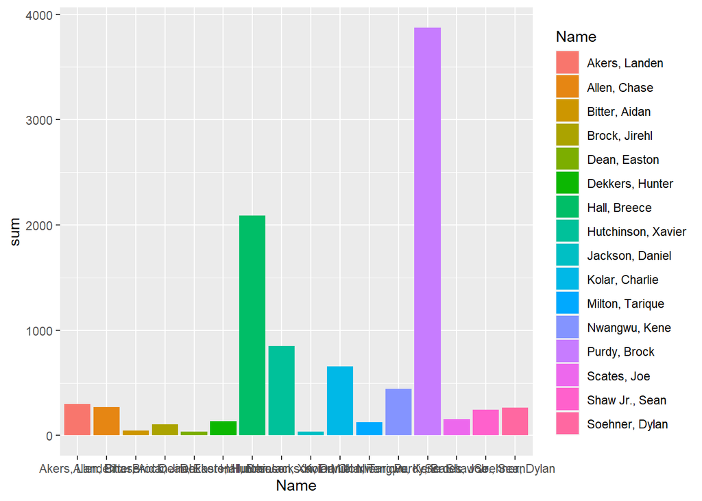

```r
ggplot(temp, aes(x = Name, y = sum, fill = Name)) + geom_bar(stat = 'identity')
```

### It really interesting to see that Purdy, Brock the quarterback of the offensive team have the highest stats compare to the rest of the teammates. The second highest stats is from Hall, Breece who looks like the receiver. ### At the end of the day, players who play an active position that are main to score points have the highest stats.

4. Did ISU have better offense against Oregon or Oklahoma? Answer this question by creating a scatterplot with the x- and y-axes being the receiving yards of the ISU players against each of these two opponents. A large number of receiving yards indicates good offense.

```r
oregon = offClean %>% filter(Opponent_Opponent %in% c('Oregon'), stat %in% c('Receiving_YDS'))
oklahoma = offClean %>% filter(Opponent_Opponent %in% c('Oklahoma'), stat %in% c('Receiving_YDS'))
oklahoma
```

```
## # A tibble: 28 x 4
## # Groups:   Name [15]
##    Name               Opponent_Opponent stat          values
##    <fct>              <fct>             <chr>          <dbl>
##  1 Akers, Landen      Oklahoma          Receiving_YDS     35
##  2 Akers, Landen      Oklahoma          Receiving_YDS     25
##  3 Brock, Jirehl      Oklahoma          Receiving_YDS      0
##  4 Brock, Jirehl      Oklahoma          Receiving_YDS      6
##  5 Hutchinson, Xavier Oklahoma          Receiving_YDS     83
##  6 Hutchinson, Xavier Oklahoma          Receiving_YDS    114
##  7 Nwangwu, Kene      Oklahoma          Receiving_YDS      0
##  8 Nwangwu, Kene      Oklahoma          Receiving_YDS      0
##  9 Purdy, Brock       Oklahoma          Receiving_YDS     NA
## 10 Purdy, Brock       Oklahoma          Receiving_YDS     NA
## # ... with 18 more rows
```

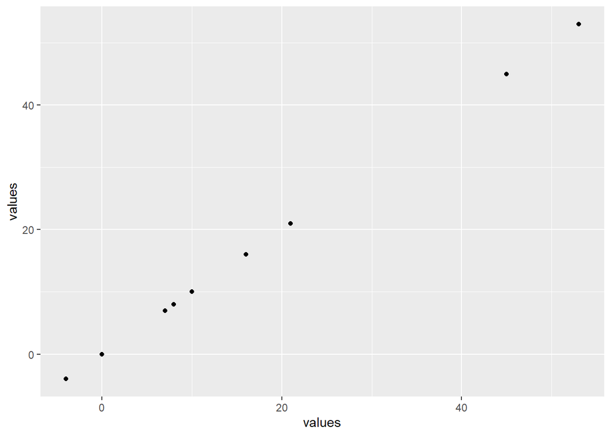

```r
ggplot(data = oregon, aes(x = values, y = values)) + geom_point()
```

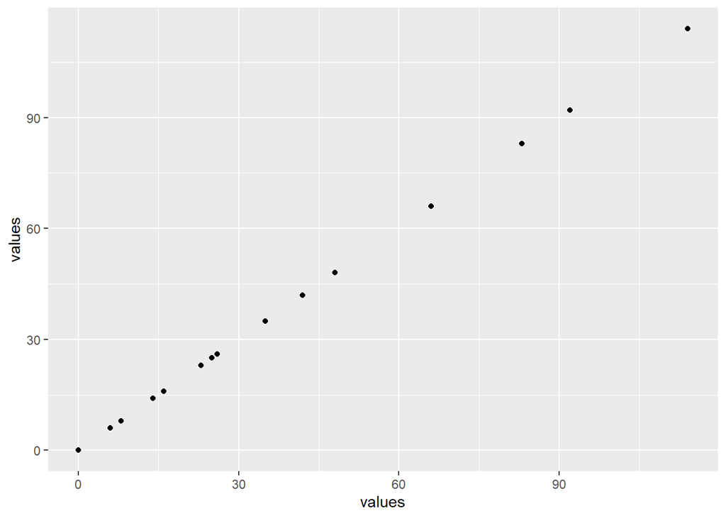

```r
ggplot(data = oklahoma, aes(x = values, y = values)) + geom_point()
```

Now turn our attention to the player biography.

5. Separate the Hometown column into two columns, namely, the city and the state where the player comes from. Print the first few rows of these two columns. (Hint: look at the sep= argument of separate)

```r
bioClean = bioClean %>% separate(Hometown, c('City', 'State'))
bioClean %>% select(City, State)
```

```
## # A tibble: 116 x 2
##    City         State
##    <chr>        <chr>
##  1 Cedar        Rapids
##  2 Nixa         Mo
##  3 Seffner      Fla
##  4 Ft           Lauderdale
##  5 Naperville   Ill
##  6 Grand        Prairie
##  7 Clarksdale   Miss
##  8 Jacksonville Fla
##  9 Jacksonville Fla
## 10 Tampa        Fla
## # ... with 106 more rows
```

6. How many players are there from each state?

```r
bioClean %>% group_by(State) %>% tally()
```

```
## # A tibble: 39 x 2
##    State         n
##    <chr>     <int>
##  1 Ariz          4
##  2 Australia     1
##  3 Beach         1
##  4 Bluffs        1
##  5 Calif         1
##  6 Center        1
##  7 City          3
##  8 Des           3
##  9 Fallon        1
## 10 Falls         1
## # ... with 29 more rows
```

7. How does the performance of quarterback Brock Purdy relate to the performance of the ISU team? Comment on both the defense and offense.

```r
offClean %>% group_by(Name) %>% filter(Name %in% c("Purdy, Brock"), stat %in% c('Passing_CMP')) %>% summarise(Avg_Pass_Completed = mean(values, na.rm = TRUE))
```

```
## # A tibble: 1 x 2
##   Name         Avg_Pass_Completed
##   <fct>                     <dbl>
## 1 Purdy, Brock               20.2
```

```r
offClean %>% group_by(Name) %>% filter(Name %in% c("Purdy, Brock"), stat %in% c('Passing_ATT')) %>% summarise(Avg_Pass_Attempted = mean(values, na.rm = TRUE))
```

```
## # A tibble: 1 x 2
##   Name         Avg_Pass_Attempted
##   <fct>                     <dbl>
## 1 Purdy, Brock               30.4
```

```r
offClean %>% group_by(stat) %>% filter(stat %in% c('Passing_CMP')) %>% summarise(Avg_Pass_Completed = mean(values, na.rm = TRUE))
```

```
## # A tibble: 1 x 2
##   stat        Avg_Pass_Completed
##   <chr>                    <dbl>
## 1 Passing_CMP               20.2
```

```r
offClean %>% group_by(stat) %>% filter(stat %in% c('Passing_ATT')) %>% summarise(Avg_Pass_Attempted = mean(values, na.rm = TRUE))
```

```
## # A tibble: 1 x 2
##   stat        Avg_Pass_Attempted
##   <chr>                    <dbl>
## 1 Passing_ATT               30.4
```

### when it comes to offensive, the action/performance of Brock Purdy will directly correspond to the team’s performance.

### Purdy’s average Pass completion is also the teams average of 20.25 throws.

### Purdy’s average pass attempted is also the teams average of 30.41667 throws.

```r
defClean %>% group_by(Name) %>% filter(Name %in% c("Purdy, Brock")) %>% summarise(Avg_Tackles_Solo = mean(Tackles_Solo, na.rm = TRUE))
```

```
## # A tibble: 1 x 2
##   Name         Avg_Tackles_Solo
##   <fct>                   <dbl>
## 1 Purdy, Brock           0.0833
```

```r
defClean %>% group_by(Name) %>% filter(Name %in% c("Purdy, Brock")) %>% summarise(Avg_Tackles_ASST = mean(Tackles_ASST, na.rm = TRUE))
```

```
## # A tibble: 1 x 2
##   Name         Avg_Tackles_ASST
##   <fct>                   <dbl>
## 1 Purdy, Brock                0
```

```r
mean(defClean$Tackles_Solo)
```

```
## [1] 0.9032258
```

```r
mean(defClean$Tackles_ASST)
```

```
## [1] 0.7446237
```

### However, it is a different story for defense as Purdy’s performance seems to have no effect on the performance of the team.

### Purdy’s average Tackles solo is 0.08333333 and average tackles assistant is 0.

### This is wildly different from the teams where the average solo tackle is 0.9032258 and average tackle assistant is 0.7446237.

### As we can see, Purdy hardly perform any tackles and never assisteted anyone. Compare to most invidual of the defensive team that performs almost 1 tackle per game and assist 0.75 tackles per game.